# Risk Factor Analysis

## Outcome Variable

**Outcome Variable:** ever_stunted

## Predictor Variables

**Intervention Variable:** exclfeed6

**Adjustment Set:**

- arm
- sex
- brthmon
- W_mage
- meducyrs
- feducyrs
- hhwealth_quart
- hfoodsec
- W_mhtcm
- W_mwtkg
- W_mbmi
- vagbrth
- W_gagebrth
- W_birthwt
- W_birthlen
- W_nrooms
- W_nchldlt5
- month
- W_parity
- impfloor
- impsan
- safeh20
- delta_W_mage
- delta_meducyrs
- delta_feducyrs
- delta_hhwealth_quart
- delta_hfoodsec
- delta_W_mhtcm
- delta_W_mwtkg
- delta_W_mbmi
- delta_vagbrth
- delta_W_gagebrth
- delta_W_birthwt
- delta_W_birthlen
- delta_W_nrooms
- delta_W_nchldlt5
- delta_month
- delta_W_parity
- delta_impfloor
- delta_impsan
- delta_safeh20

## Stratifying Variables

The analysis was stratified on these variable(s):

- agecat
- studyid
- country

## Data Summary

| agecat | studyid | country | exclfeed6 | ever_stunted | n_cell | n |
| --- | --- | --- | --- | --- | --- | --- |
| 0-24 months (no birth st.) | CMC-V-BCS-2002 | INDIA | 1 | 0 | 1 | 14 |
| 0-24 months (no birth st.) | CMC-V-BCS-2002 | INDIA | 1 | 1 | 13 | 14 |
| 0-24 months (no birth st.) | CMC-V-BCS-2002 | INDIA | 0 | 0 | 0 | 14 |
| 0-24 months (no birth st.) | CMC-V-BCS-2002 | INDIA | 0 | 1 | 0 | 14 |
| 0-24 months (no birth st.) | EE | PAKISTAN | 1 | 0 | 4 | 27 |
| 0-24 months (no birth st.) | EE | PAKISTAN | 1 | 1 | 19 | 27 |
| 0-24 months (no birth st.) | EE | PAKISTAN | 0 | 0 | 2 | 27 |
| 0-24 months (no birth st.) | EE | PAKISTAN | 0 | 1 | 2 | 27 |
| 0-24 months (no birth st.) | GMS-Nepal | NEPAL | 1 | 0 | 130 | 471 |
| 0-24 months (no birth st.) | GMS-Nepal | NEPAL | 1 | 1 | 222 | 471 |
| 0-24 months (no birth st.) | GMS-Nepal | NEPAL | 0 | 0 | 34 | 471 |
| 0-24 months (no birth st.) | GMS-Nepal | NEPAL | 0 | 1 | 85 | 471 |
| 0-24 months (no birth st.) | IRC | INDIA | 1 | 0 | 0 | 13 |
| 0-24 months (no birth st.) | IRC | INDIA | 1 | 1 | 0 | 13 |
| 0-24 months (no birth st.) | IRC | INDIA | 0 | 0 | 4 | 13 |
| 0-24 months (no birth st.) | IRC | INDIA | 0 | 1 | 9 | 13 |
| 0-24 months (no birth st.) | JiVitA-3 | BANGLADESH | 1 | 0 | 6237 | 10809 |
| 0-24 months (no birth st.) | JiVitA-3 | BANGLADESH | 1 | 1 | 2188 | 10809 |
| 0-24 months (no birth st.) | JiVitA-3 | BANGLADESH | 0 | 0 | 1786 | 10809 |
| 0-24 months (no birth st.) | JiVitA-3 | BANGLADESH | 0 | 1 | 598 | 10809 |
| 0-24 months (no birth st.) | JiVitA-4 | BANGLADESH | 1 | 0 | 1558 | 3397 |
| 0-24 months (no birth st.) | JiVitA-4 | BANGLADESH | 1 | 1 | 1122 | 3397 |
| 0-24 months (no birth st.) | JiVitA-4 | BANGLADESH | 0 | 0 | 400 | 3397 |
| 0-24 months (no birth st.) | JiVitA-4 | BANGLADESH | 0 | 1 | 317 | 3397 |
| 0-24 months (no birth st.) | Keneba | GAMBIA | 1 | 0 | 401 | 2023 |
| 0-24 months (no birth st.) | Keneba | GAMBIA | 1 | 1 | 350 | 2023 |
| 0-24 months (no birth st.) | Keneba | GAMBIA | 0 | 0 | 566 | 2023 |
| 0-24 months (no birth st.) | Keneba | GAMBIA | 0 | 1 | 706 | 2023 |
| 0-24 months (no birth st.) | LCNI-5 | MALAWI | 1 | 0 | 18 | 175 |
| 0-24 months (no birth st.) | LCNI-5 | MALAWI | 1 | 1 | 12 | 175 |

[output cut: 114 more lines]

The following strata were considered:

- agecat: 0-24 months (no birth st.), studyid: CMC-V-BCS-2002, country: INDIA
- agecat: 0-24 months (no birth st.), studyid: EE, country: PAKISTAN
- agecat: 0-24 months (no birth st.), studyid: GMS-Nepal, country: NEPAL
- agecat: 0-24 months (no birth st.), studyid: IRC, country: INDIA
- agecat: 0-24 months (no birth st.), studyid: JiVitA-3, country: BANGLADESH
- agecat: 0-24 months (no birth st.), studyid: JiVitA-4, country: BANGLADESH
- agecat: 0-24 months (no birth st.), studyid: Keneba, country: GAMBIA
- agecat: 0-24 months (no birth st.), studyid: LCNI-5, country: MALAWI
- agecat: 0-24 months (no birth st.), studyid: MAL-ED, country: BANGLADESH
- agecat: 0-24 months (no birth st.), studyid: MAL-ED, country: BRAZIL
- agecat: 0-24 months (no birth st.), studyid: MAL-ED, country: INDIA
- agecat: 0-24 months (no birth st.), studyid: MAL-ED, country: NEPAL
- agecat: 0-24 months (no birth st.), studyid: MAL-ED, country: PERU
- agecat: 0-24 months (no birth st.), studyid: MAL-ED, country: SOUTH AFRICA
- agecat: 0-24 months (no birth st.), studyid: MAL-ED, country: TANZANIA, UNITED REPUBLIC OF
- agecat: 0-24 months (no birth st.), studyid: PROVIDE, country: BANGLADESH
- agecat: 0-24 months (no birth st.), studyid: SAS-CompFeed, country: INDIA
- agecat: 0-24 months (no birth st.), studyid: SAS-FoodSuppl, country: INDIA
- agecat: 0-6 months (no birth st.), studyid: CMC-V-BCS-2002, country: INDIA
- agecat: 0-6 months (no birth st.), studyid: EE, country: PAKISTAN
- agecat: 0-6 months (no birth st.), studyid: GMS-Nepal, country: NEPAL
- agecat: 0-6 months (no birth st.), studyid: IRC, country: INDIA
- agecat: 0-6 months (no birth st.), studyid: JiVitA-3, country: BANGLADESH
- agecat: 0-6 months (no birth st.), studyid: JiVitA-4, country: BANGLADESH
- agecat: 0-6 months (no birth st.), studyid: Keneba, country: GAMBIA
- agecat: 0-6 months (no birth st.), studyid: LCNI-5, country: MALAWI
- agecat: 0-6 months (no birth st.), studyid: MAL-ED, country: BANGLADESH
- agecat: 0-6 months (no birth st.), studyid: MAL-ED, country: BRAZIL
- agecat: 0-6 months (no birth st.), studyid: MAL-ED, country: INDIA
- agecat: 0-6 months (no birth st.), studyid: MAL-ED, country: NEPAL
- agecat: 0-6 months (no birth st.), studyid: MAL-ED, country: PERU
- agecat: 0-6 months (no birth st.), studyid: MAL-ED, country: SOUTH AFRICA
- agecat: 0-6 months (no birth st.), studyid: MAL-ED, country: TANZANIA, UNITED REPUBLIC OF
- agecat: 0-6 months (no birth st.), studyid: PROVIDE, country: BANGLADESH
- agecat: 0-6 months (no birth st.), studyid: SAS-CompFeed, country: INDIA
- agecat: 0-6 months (no birth st.), studyid: SAS-FoodSuppl, country: INDIA

### Dropped Strata

Some strata were dropped due to rare outcomes:

- agecat: 0-24 months (no birth st.), studyid: CMC-V-BCS-2002, country: INDIA
- agecat: 0-24 months (no birth st.), studyid: EE, country: PAKISTAN
- agecat: 0-24 months (no birth st.), studyid: IRC, country: INDIA
- agecat: 0-24 months (no birth st.), studyid: MAL-ED, country: BRAZIL
- agecat: 0-24 months (no birth st.), studyid: MAL-ED, country: INDIA
- agecat: 0-24 months (no birth st.), studyid: MAL-ED, country: NEPAL
- agecat: 0-24 months (no birth st.), studyid: MAL-ED, country: PERU
- agecat: 0-24 months (no birth st.), studyid: MAL-ED, country: SOUTH AFRICA
- agecat: 0-24 months (no birth st.), studyid: MAL-ED, country: TANZANIA, UNITED REPUBLIC OF
- agecat: 0-24 months (no birth st.), studyid: SAS-FoodSuppl, country: INDIA
- agecat: 0-6 months (no birth st.), studyid: CMC-V-BCS-2002, country: INDIA
- agecat: 0-6 months (no birth st.), studyid: EE, country: PAKISTAN
- agecat: 0-6 months (no birth st.), studyid: IRC, country: INDIA
- agecat: 0-6 months (no birth st.), studyid: LCNI-5, country: MALAWI
- agecat: 0-6 months (no birth st.), studyid: MAL-ED, country: BRAZIL
- agecat: 0-6 months (no birth st.), studyid: MAL-ED, country: INDIA
- agecat: 0-6 months (no birth st.), studyid: MAL-ED, country: NEPAL
- agecat: 0-6 months (no birth st.), studyid: MAL-ED, country: PERU
- agecat: 0-6 months (no birth st.), studyid: MAL-ED, country: SOUTH AFRICA
- agecat: 0-6 months (no birth st.), studyid: MAL-ED, country: TANZANIA, UNITED REPUBLIC OF
- agecat: 0-6 months (no birth st.), studyid: SAS-FoodSuppl, country: INDIA

## Methods Detail

We're interested in the causal parameters $E[Y_a]$ for all values of $a \in \mathcal{A}$. These parameters represent the mean outcome if, possibly contrary to fact, we intervened to set all units to have $A=a$. Under the randomization and positivity assumptions, these are identified by the statistical parameters $\psi_a=E_W[E_{Y|A,W}(Y|A=a,W)]$. In addition, we're interested in the mean of $Y$, $E[Y]$ under no intervention (the observed mean). We will estimate these parameters by using SuperLearner to fit the relevant likelihood factors -- $E_{Y|A,W}(Y|A=a,W)$ and $p(A=a|W)$, and then updating our likelihood fit using a joint TMLE.

For unadjusted analyses ($W=\{\}$), initial likelihoods were estimated using Lrnr_glm to estimate the simple $E(Y|A)$ and Lrnr_mean to estimate $p(A)$. For adjusted analyses, a small library containing Lrnr_glmnet, Lrnr_xgboost, and Lrnr_mean was used.

Having estimated these parameters, we will then use the delta method to estimate relative risks and attributable risks relative to a prespecified baseline level of $A$.

# Results Detail

## Results Plots

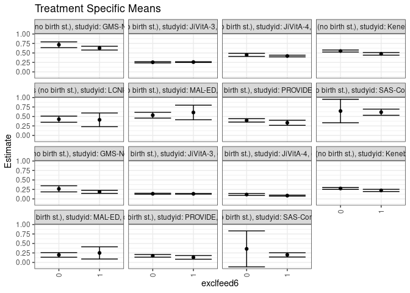

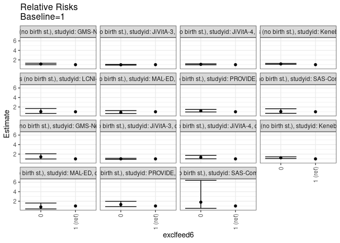

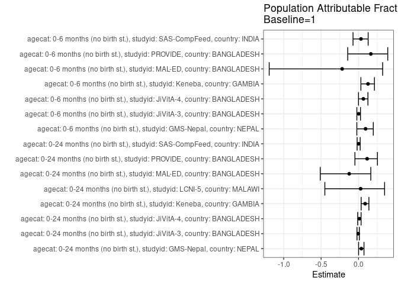

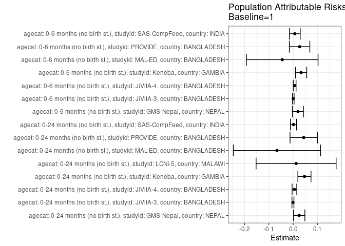

## Results Table

### Parameter: TSM

| agecat | studyid | country | intervention_level | baseline_level | estimate | ci_lower | ci_upper |
| --- | --- | --- | --- | --- | --- | --- | --- |
| 0-24 months (no birth st.) | GMS-Nepal | NEPAL | 1 | NA | 0.6271147 | 0.5767950 | 0.6774345 |
| 0-24 months (no birth st.) | GMS-Nepal | NEPAL | 0 | NA | 0.7159048 | 0.6396831 | 0.7921264 |
| 0-24 months (no birth st.) | JiVitA-3 | BANGLADESH | 1 | NA | 0.2588441 | 0.2478334 | 0.2698548 |
| 0-24 months (no birth st.) | JiVitA-3 | BANGLADESH | 0 | NA | 0.2536962 | 0.2368412 | 0.2705512 |
| 0-24 months (no birth st.) | JiVitA-4 | BANGLADESH | 1 | NA | 0.4185291 | 0.3966845 | 0.4403737 |
| 0-24 months (no birth st.) | JiVitA-4 | BANGLADESH | 0 | NA | 0.4484277 | 0.4075678 | 0.4892875 |
| 0-24 months (no birth st.) | Keneba | GAMBIA | 1 | NA | 0.4757636 | 0.4411067 | 0.5104205 |
| 0-24 months (no birth st.) | Keneba | GAMBIA | 0 | NA | 0.5505387 | 0.5237293 | 0.5773481 |
| 0-24 months (no birth st.) | LCNI-5 | MALAWI | 1 | NA | 0.4109227 | 0.2306720 | 0.5911734 |
| 0-24 months (no birth st.) | LCNI-5 | MALAWI | 0 | NA | 0.4272017 | 0.3463738 | 0.5080295 |
| 0-24 months (no birth st.) | MAL-ED | BANGLADESH | 1 | NA | 0.6052428 | 0.4128818 | 0.7976039 |
| 0-24 months (no birth st.) | MAL-ED | BANGLADESH | 0 | NA | 0.5324143 | 0.4564172 | 0.6084113 |
| 0-24 months (no birth st.) | PROVIDE | BANGLADESH | 1 | NA | 0.3326930 | 0.2657630 | 0.3996230 |
| 0-24 months (no birth st.) | PROVIDE | BANGLADESH | 0 | NA | 0.3963823 | 0.3512656 | 0.4414989 |
| 0-24 months (no birth st.) | SAS-CompFeed | INDIA | 1 | NA | 0.6121795 | 0.5306906 | 0.6936683 |
| 0-24 months (no birth st.) | SAS-CompFeed | INDIA | 0 | NA | 0.6428571 | 0.3329177 | 0.9527966 |
| 0-6 months (no birth st.) | GMS-Nepal | NEPAL | 1 | NA | 0.1865236 | 0.1456974 | 0.2273497 |
| 0-6 months (no birth st.) | GMS-Nepal | NEPAL | 0 | NA | 0.2654081 | 0.1848376 | 0.3459786 |
| 0-6 months (no birth st.) | JiVitA-3 | BANGLADESH | 1 | NA | 0.1343065 | 0.1260628 | 0.1425501 |
| 0-6 months (no birth st.) | JiVitA-3 | BANGLADESH | 0 | NA | 0.1357684 | 0.1227700 | 0.1487669 |
| 0-6 months (no birth st.) | JiVitA-4 | BANGLADESH | 1 | NA | 0.0865864 | 0.0730844 | 0.1000884 |
| 0-6 months (no birth st.) | JiVitA-4 | BANGLADESH | 0 | NA | 0.1153940 | 0.0900613 | 0.1407267 |
| 0-6 months (no birth st.) | Keneba | GAMBIA | 1 | NA | 0.2235229 | 0.1945549 | 0.2524910 |
| 0-6 months (no birth st.) | Keneba | GAMBIA | 0 | NA | 0.2752197 | 0.2510488 | 0.2993906 |
| 0-6 months (no birth st.) | MAL-ED | BANGLADESH | 1 | NA | 0.2500000 | 0.0892000 | 0.4108000 |
| 0-6 months (no birth st.) | MAL-ED | BANGLADESH | 0 | NA | 0.1976048 | 0.1370569 | 0.2581527 |
| 0-6 months (no birth st.) | PROVIDE | BANGLADESH | 1 | NA | 0.1331990 | 0.0842083 | 0.1821897 |
| 0-6 months (no birth st.) | PROVIDE | BANGLADESH | 0 | NA | 0.1736332 | 0.1383088 | 0.2089576 |
| 0-6 months (no birth st.) | SAS-CompFeed | INDIA | 1 | NA | 0.1987179 | 0.1419130 | 0.2555229 |
| 0-6 months (no birth st.) | SAS-CompFeed | INDIA | 0 | NA | 0.3571429 | -0.1170496 | 0.8313354 |

### Parameter: E(Y)

| agecat | studyid | country | intervention_level | baseline_level | estimate | ci_lower | ci_upper |
| --- | --- | --- | --- | --- | --- | --- | --- |
| 0-24 months (no birth st.) | GMS-Nepal | NEPAL | NA | NA | 0.6518047 | 0.6087352 | 0.6948741 |
| 0-24 months (no birth st.) | JiVitA-3 | BANGLADESH | NA | NA | 0.2577482 | 0.2478575 | 0.2676389 |
| 0-24 months (no birth st.) | JiVitA-4 | BANGLADESH | NA | NA | 0.4236091 | 0.4038600 | 0.4433581 |
| 0-24 months (no birth st.) | Keneba | GAMBIA | NA | NA | 0.5219970 | 0.5002246 | 0.5437695 |
| 0-24 months (no birth st.) | LCNI-5 | MALAWI | NA | NA | 0.4228571 | 0.3494545 | 0.4962598 |
| 0-24 months (no birth st.) | MAL-ED | BANGLADESH | NA | NA | 0.5384615 | 0.4683114 | 0.6086117 |
| 0-24 months (no birth st.) | PROVIDE | BANGLADESH | NA | NA | 0.3759874 | 0.3382238 | 0.4137509 |
| 0-24 months (no birth st.) | SAS-CompFeed | INDIA | NA | NA | 0.6134969 | 0.5286303 | 0.6983636 |
| 0-6 months (no birth st.) | GMS-Nepal | NEPAL | NA | NA | 0.2059448 | 0.1693853 | 0.2425043 |
| 0-6 months (no birth st.) | JiVitA-3 | BANGLADESH | NA | NA | 0.1346474 | 0.1274032 | 0.1418916 |
| 0-6 months (no birth st.) | JiVitA-4 | BANGLADESH | NA | NA | 0.0926091 | 0.0806150 | 0.1046031 |
| 0-6 months (no birth st.) | Keneba | GAMBIA | NA | NA | 0.2560554 | 0.2370317 | 0.2750791 |
| 0-6 months (no birth st.) | MAL-ED | BANGLADESH | NA | NA | 0.2051282 | 0.1483073 | 0.2619492 |
| 0-6 months (no birth st.) | PROVIDE | BANGLADESH | NA | NA | 0.1595577 | 0.1310079 | 0.1881074 |
| 0-6 months (no birth st.) | SAS-CompFeed | INDIA | NA | NA | 0.2055215 | 0.1385538 | 0.2724891 |

### Parameter: RR

| agecat | studyid | country | intervention_level | baseline_level | estimate | ci_lower | ci_upper |
| --- | --- | --- | --- | --- | --- | --- | --- |
| 0-24 months (no birth st.) | GMS-Nepal | NEPAL | 1 | 1 | 1.0000000 | 1.0000000 | 1.000000 |
| 0-24 months (no birth st.) | GMS-Nepal | NEPAL | 0 | 1 | 1.1415850 | 1.0020237 | 1.300584 |
| 0-24 months (no birth st.) | JiVitA-3 | BANGLADESH | 1 | 1 | 1.0000000 | 1.0000000 | 1.000000 |
| 0-24 months (no birth st.) | JiVitA-3 | BANGLADESH | 0 | 1 | 0.9801121 | 0.9112530 | 1.054175 |
| 0-24 months (no birth st.) | JiVitA-4 | BANGLADESH | 1 | 1 | 1.0000000 | 1.0000000 | 1.000000 |
| 0-24 months (no birth st.) | JiVitA-4 | BANGLADESH | 0 | 1 | 1.0714373 | 0.9679148 | 1.186032 |
| 0-24 months (no birth st.) | Keneba | GAMBIA | 1 | 1 | 1.0000000 | 1.0000000 | 1.000000 |
| 0-24 months (no birth st.) | Keneba | GAMBIA | 0 | 1 | 1.1571686 | 1.0629160 | 1.259779 |
| 0-24 months (no birth st.) | LCNI-5 | MALAWI | 1 | 1 | 1.0000000 | 1.0000000 | 1.000000 |
| 0-24 months (no birth st.) | LCNI-5 | MALAWI | 0 | 1 | 1.0396156 | 0.6450822 | 1.675447 |
| 0-24 months (no birth st.) | MAL-ED | BANGLADESH | 1 | 1 | 1.0000000 | 1.0000000 | 1.000000 |
| 0-24 months (no birth st.) | MAL-ED | BANGLADESH | 0 | 1 | 0.8796705 | 0.6200626 | 1.247971 |
| 0-24 months (no birth st.) | PROVIDE | BANGLADESH | 1 | 1 | 1.0000000 | 1.0000000 | 1.000000 |
| 0-24 months (no birth st.) | PROVIDE | BANGLADESH | 0 | 1 | 1.1914354 | 0.9528115 | 1.489821 |
| 0-24 months (no birth st.) | SAS-CompFeed | INDIA | 1 | 1 | 1.0000000 | 1.0000000 | 1.000000 |
| 0-24 months (no birth st.) | SAS-CompFeed | INDIA | 0 | 1 | 1.0501122 | 0.6736522 | 1.636951 |
| 0-6 months (no birth st.) | GMS-Nepal | NEPAL | 1 | 1 | 1.0000000 | 1.0000000 | 1.000000 |
| 0-6 months (no birth st.) | GMS-Nepal | NEPAL | 0 | 1 | 1.4229200 | 0.9784745 | 2.069243 |
| 0-6 months (no birth st.) | JiVitA-3 | BANGLADESH | 1 | 1 | 1.0000000 | 1.0000000 | 1.000000 |
| 0-6 months (no birth st.) | JiVitA-3 | BANGLADESH | 0 | 1 | 1.0108853 | 0.9060286 | 1.127878 |
| 0-6 months (no birth st.) | JiVitA-4 | BANGLADESH | 1 | 1 | 1.0000000 | 1.0000000 | 1.000000 |
| 0-6 months (no birth st.) | JiVitA-4 | BANGLADESH | 0 | 1 | 1.3327038 | 1.0203040 | 1.740755 |
| 0-6 months (no birth st.) | Keneba | GAMBIA | 1 | 1 | 1.0000000 | 1.0000000 | 1.000000 |
| 0-6 months (no birth st.) | Keneba | GAMBIA | 0 | 1 | 1.2312820 | 1.0568690 | 1.434478 |
| 0-6 months (no birth st.) | MAL-ED | BANGLADESH | 1 | 1 | 1.0000000 | 1.0000000 | 1.000000 |
| 0-6 months (no birth st.) | MAL-ED | BANGLADESH | 0 | 1 | 0.7904192 | 0.3876519 | 1.611658 |
| 0-6 months (no birth st.) | PROVIDE | BANGLADESH | 1 | 1 | 1.0000000 | 1.0000000 | 1.000000 |
| 0-6 months (no birth st.) | PROVIDE | BANGLADESH | 0 | 1 | 1.3035619 | 0.8574597 | 1.981753 |
| 0-6 months (no birth st.) | SAS-CompFeed | INDIA | 1 | 1 | 1.0000000 | 1.0000000 | 1.000000 |
| 0-6 months (no birth st.) | SAS-CompFeed | INDIA | 0 | 1 | 1.7972350 | 0.5064696 | 6.377587 |

### Parameter: PAR

| agecat | studyid | country | intervention_level | baseline_level | estimate | ci_lower | ci_upper |
| --- | --- | --- | --- | --- | --- | --- | --- |
| 0-24 months (no birth st.) | GMS-Nepal | NEPAL | 1 | NA | 0.0246899 | 0.0013747 | 0.0480052 |
| 0-24 months (no birth st.) | JiVitA-3 | BANGLADESH | 1 | NA | -0.0010959 | -0.0051934 | 0.0030016 |
| 0-24 months (no birth st.) | JiVitA-4 | BANGLADESH | 1 | NA | 0.0050800 | -0.0045329 | 0.0146929 |
| 0-24 months (no birth st.) | Keneba | GAMBIA | 1 | NA | 0.0462334 | 0.0192616 | 0.0732053 |
| 0-24 months (no birth st.) | LCNI-5 | MALAWI | 1 | NA | 0.0119344 | -0.1525331 | 0.1764020 |
| 0-24 months (no birth st.) | MAL-ED | BANGLADESH | 1 | NA | -0.0667813 | -0.2459589 | 0.1123963 |
| 0-24 months (no birth st.) | PROVIDE | BANGLADESH | 1 | NA | 0.0432943 | -0.0129774 | 0.0995661 |
| 0-24 months (no birth st.) | SAS-CompFeed | INDIA | 1 | NA | 0.0013174 | -0.0112602 | 0.0138950 |
| 0-6 months (no birth st.) | GMS-Nepal | NEPAL | 1 | NA | 0.0194212 | -0.0032986 | 0.0421411 |
| 0-6 months (no birth st.) | JiVitA-3 | BANGLADESH | 1 | NA | 0.0003409 | -0.0029262 | 0.0036080 |
| 0-6 months (no birth st.) | JiVitA-4 | BANGLADESH | 1 | NA | 0.0060227 | 0.0002845 | 0.0117609 |
| 0-6 months (no birth st.) | Keneba | GAMBIA | 1 | NA | 0.0325325 | 0.0093654 | 0.0556995 |
| 0-6 months (no birth st.) | MAL-ED | BANGLADESH | 1 | NA | -0.0448718 | -0.1920444 | 0.1023008 |
| 0-6 months (no birth st.) | PROVIDE | BANGLADESH | 1 | NA | 0.0263586 | -0.0157278 | 0.0684450 |
| 0-6 months (no birth st.) | SAS-CompFeed | INDIA | 1 | NA | 0.0068035 | -0.0151879 | 0.0287949 |

### Parameter: PAF

| agecat | studyid | country | intervention_level | baseline_level | estimate | ci_lower | ci_upper |
| --- | --- | --- | --- | --- | --- | --- | --- |
| 0-24 months (no birth st.) | GMS-Nepal | NEPAL | 1 | NA | 0.0378793 | 0.0011731 | 0.0732366 |
| 0-24 months (no birth st.) | JiVitA-3 | BANGLADESH | 1 | NA | -0.0042518 | -0.0202630 | 0.0115082 |
| 0-24 months (no birth st.) | JiVitA-4 | BANGLADESH | 1 | NA | 0.0119921 | -0.0109625 | 0.0344255 |
| 0-24 months (no birth st.) | Keneba | GAMBIA | 1 | NA | 0.0885703 | 0.0352689 | 0.1389268 |
| 0-24 months (no birth st.) | LCNI-5 | MALAWI | 1 | NA | 0.0282234 | -0.4501299 | 0.3487826 |
| 0-24 months (no birth st.) | MAL-ED | BANGLADESH | 1 | NA | -0.1240224 | -0.5118258 | 0.1643043 |
| 0-24 months (no birth st.) | PROVIDE | BANGLADESH | 1 | NA | 0.1151483 | -0.0480826 | 0.2529573 |
| 0-24 months (no birth st.) | SAS-CompFeed | INDIA | 1 | NA | 0.0021474 | -0.0184658 | 0.0223435 |
| 0-6 months (no birth st.) | GMS-Nepal | NEPAL | 1 | NA | 0.0943031 | -0.0223331 | 0.1976325 |
| 0-6 months (no birth st.) | JiVitA-3 | BANGLADESH | 1 | NA | 0.0025321 | -0.0220441 | 0.0265174 |
| 0-6 months (no birth st.) | JiVitA-4 | BANGLADESH | 1 | NA | 0.0650334 | 0.0000066 | 0.1258317 |
| 0-6 months (no birth st.) | Keneba | GAMBIA | 1 | NA | 0.1270524 | 0.0318810 | 0.2128680 |
| 0-6 months (no birth st.) | MAL-ED | BANGLADESH | 1 | NA | -0.2187500 | -1.1940228 | 0.3230009 |
| 0-6 months (no birth st.) | PROVIDE | BANGLADESH | 1 | NA | 0.1651981 | -0.1441295 | 0.3908957 |
| 0-6 months (no birth st.) | SAS-CompFeed | INDIA | 1 | NA | 0.0331037 | -0.0733606 | 0.1290081 |